# Reading and writing files - hands-on exercise

## Task 6: Analyzing (part 1, erroneous)

Using **dream_island_penguins,** create a box plot where x = year, y = bill_length_mm.

This will look wrong which we will fix in Task 7. What could be the issue (hint: data types)? **Note:** the year variable contains 2007-2009 data.

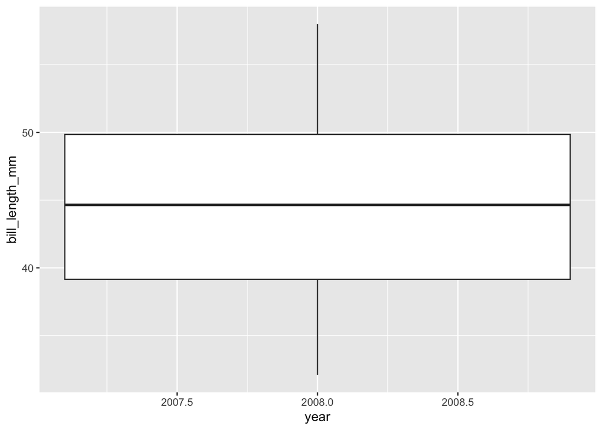

```r
# Place your script(s) below:
ggplot(data = dream_island_penguins,
       aes(x = year, y = bill_length_mm)) +
  geom_boxplot()
```

## Task 7: Analyzing (part 2, correcting Task 6)

This time, copy your code from Task 6 into the code chunk below. However, this time, use x = as.character(year) instead.

Context: Since R expects one categorical variable to create a boxplot, you will need to make year, which is a numeric variable, into a string or character type. This concept of forcing year, a numeric variable, into character/string type is known as *explicit coercion.*

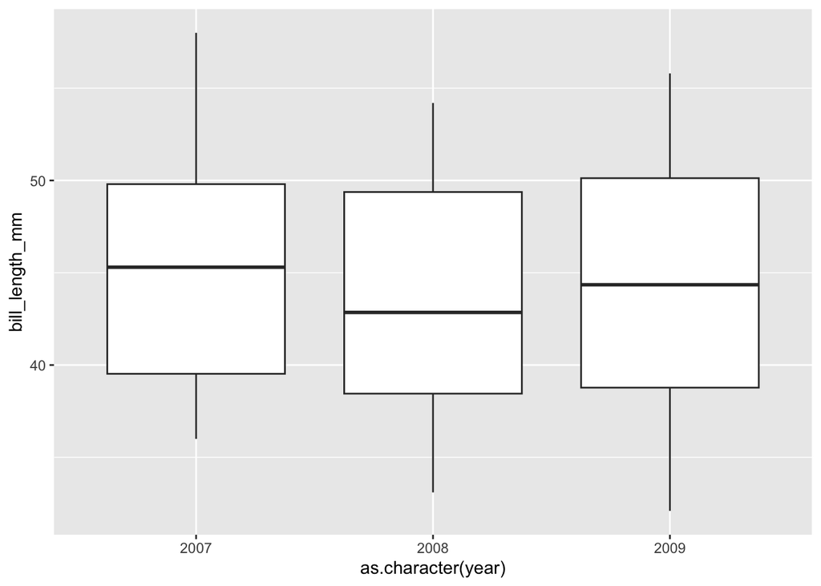

```r
# Place your script(s) below:
ggplot(data = dream_island_penguins,
       aes(x = as.character(year), y = bill_length_mm)) +
  geom_boxplot()
```